# Deep Learning CA2 Part A

### CIFAR-10 Image Generation: EDA and Preprocessing

| Student | Primary Responsibility |
| --- | --- |
| Agne Rudhresh | GAN track and notebook integration |
| Mohamad Aniq Bin Mohamad Hisyam | VAE track |

**Notebook:** `01_INTRO_CIFAR10_EDA_and_Preprocessing.ipynb`  
**Dataset:** CIFAR-10  
**Main approaches:** Generative Adversarial Network and Variational Autoencoder  
**Project objective:** Generate and evaluate synthetic images representing all 10 CIFAR-10 classes

## 1. Project Introduction and Background

This section introduces the CIFAR-10 image-generation task and the two approaches used in this project: a Generative Adversarial Network and a Variational Autoencoder.

It also explains how EDA and selected image features will be used to understand the dataset, guide later model experiments, and support the evaluation of generated images.

### 1.1 Problem Background and Project Aim

Image classification learns to assign a label to an existing image. Image generation addresses a different problem: learning a representation of the image distribution that can be sampled to produce new synthetic images.

Unlike classification, there is no single correct output for a given latent input. Many generated images may be valid, provided that they resemble the data distribution while remaining sufficiently varied and recognisable.

This creates several competing objectives:

- **visual quality**, where outputs should contain plausible colours, textures, and object structure
- **recognisability**, where outputs should contain meaningful CIFAR-10 class characteristics
- **diversity**, where the model should generate varied samples rather than repeatedly producing similar images
- **class coverage**, where all 10 classes should be represented
- **training reliability**, where useful results should not depend on one unstable or unusually successful run
- **originality**, where generated outputs should not simply reproduce training images

Training loss alone cannot answer all these questions. A model may achieve favourable optimisation behaviour while still producing repetitive, ambiguous, or poorly structured images. This project therefore treats model losses as diagnostic evidence rather than complete measures of generation quality.

The project investigates the following questions:

1. How effectively can GAN and VAE approaches generate plausible CIFAR-10 images?
2. Which approach provides the stronger balance of quality, recognisability, diversity, stability, and reproducibility?
3. Which CIFAR-10 classes appear easier or harder to generate, and what dataset characteristics may explain the differences?
4. How important is RGB colour information for recognisability?
5. Can restrained augmentation improve generation without distorting the original data distribution?
6. Do the final outputs show evidence of repetition or possible memorisation?
7. How can the selected generative approach produce images from a requested CIFAR-10 class?

The final deliverable will contain 1,000 generated images covering all 10 CIFAR-10 classes.

#### Project workflow

| Notebook | Purpose |
| --- | --- |
| `01_INTRO_CIFAR10_EDA_and_Preprocessing.ipynb` | Dataset analysis, feature engineering, and shared preprocessing |
| `02_GAN_Experiments.ipynb` | GAN baseline, controlled improvements, and final GAN selection |
| `03_VAE_Experiments.ipynb` | VAE baseline, controlled improvements, and final VAE selection |
| `04_GAN_vs_VAE_Comparison_and_Final_Selection.ipynb` | Shared evaluation, final model comparison, and final image generation |

Neither model family is assumed to be superior before experimentation. The final selection will be based on evidence gathered under shared evaluation conditions.

### 1.2 CIFAR-10 as a Generative Modelling Task

CIFAR-10 contains 60,000 colour images divided evenly across 10 object classes. Each image has a resolution of 32 × 32 pixels and three RGB channels. The official dataset contains 50,000 training images and 10,000 test images ([Krizhevsky, 2009](https://www.cs.toronto.edu/~kriz/cifar.html)).

| Property | CIFAR-10 specification |
| --- | --- |
| Total images | 60,000 |
| Training images | 50,000 |
| Test images | 10,000 |
| Resolution | 32 × 32 pixels |
| Colour format | RGB |
| Classes | 10 |
| Images per class (total) | 6,000 |
| Images per class (training) | 5,000 |

The classes are airplane, automobile, bird, cat, deer, dog, frog, horse, ship, and truck.

Although CIFAR-10 is computationally manageable, its low resolution makes image generation challenging. Fine class-specific details may occupy only a small number of pixels, so an image can contain realistic colours and textures while still lacking recognisable object structure.

Three possible sources of generation difficulty will be investigated rather than assumed:

#### Within-class variation

Images belonging to the same class may vary in pose, viewpoint, scale, position, crop, colour, and background. A successful model must therefore represent multiple valid appearances rather than reproduce one average class template.

#### Similarity between classes

Some classes may share visual features, particularly:

- cat and dog
- deer and horse
- automobile and truck
- airplane and ship

At 32 × 32 resolution, the details separating these classes may be weak.

#### Background dependence

The labelled object may occupy only part of an image. A model could learn common sky, road, grass, or water patterns without learning sufficient object structure.

The EDA will examine whether these challenges are visible in the supplied training data. Final conclusions about generation difficulty will only be made after comparing the real-data evidence with outputs from both models.

### 1.3 Proposed Approaches: GAN and VAE

This project compares two generative frameworks with different learning mechanisms.

#### Generative Adversarial Network

A GAN trains two neural networks through an adversarial objective ([Goodfellow et al., 2014](https://proceedings.neurips.cc/paper/5423-generative-adversarial-nets)):

- the **generator** transforms a sampled latent vector into a synthetic image
- the **discriminator** estimates whether an image originates from the real training data or the generator

The generator improves by learning to produce outputs that the discriminator finds increasingly difficult to distinguish from real images.

The GAN track will begin with a convolutional DCGAN-style baseline, an approach designed for learning image representations using convolutional generator and discriminator networks ([Radford, Metz, & Chintala, 2016](https://arxiv.org/abs/1511.06434)).

The main questions investigated in the GAN notebook will include:

- whether generator and discriminator learning remain balanced
- whether generated quality improves consistently
- whether mode collapse or repeated outputs occur
- whether all classes and visual patterns are represented
- whether controlled stabilisation methods improve results

GAN losses will be monitored, but checkpoint selection will also use fixed latent samples, diversity evidence, recognisability, stability, and distribution-level evaluation.

#### Variational Autoencoder

A VAE learns a probabilistic latent-variable model using an encoder and decoder ([Kingma & Welling, 2014](https://openreview.net/forum?id=33X9fd2-9FyZd)).

The encoder maps each input image to parameters of a latent probability distribution. A latent representation is sampled using the reparameterisation procedure and passed to the decoder, which attempts to reconstruct the image.

The VAE objective combines:

- a **reconstruction term**, which encourages the output to resemble the input
- a **KL-divergence term**, which regularises the latent distribution

The VAE track will use a convolutional encoder and decoder suitable for RGB image data. Its experiments will investigate:

- reconstruction and generation quality
- the balance between reconstruction and KL regularisation
- latent-space utilisation
- possible posterior collapse
- colour and edge preservation
- class coverage and sample diversity

#### Why both approaches are compared

The GAN and VAE optimise different objectives and may fail in different ways. The GAN may produce visually stronger images but require careful stability and diversity monitoring. The VAE provides an explicit encoder and regularised latent representation, but its generated outputs must be examined for smoothing and loss of structural detail.

These are expected trade-offs, not predetermined conclusions. Both models will be developed independently and compared using the same final evaluation framework.

### 1.4 Role of EDA, Feature Engineering, and Evaluation

The purpose of the EDA is not only to describe CIFAR-10. It is to identify dataset properties that influence later modelling and evaluation decisions.

The analysis examines:

- class balance
- realistic within-class variation
- object and background characteristics
- similarities between selected classes
- colour and intensity distributions
- RGB versus grayscale information
- augmentation suitability
- preliminary hypotheses about class difficulty

#### Engineered image descriptors

A small set of interpretable image descriptors will be calculated from every training image.

| Descriptor | Property represented | Later use |
| --- | --- | --- |
| Brightness | Overall perceptual luminance | Detect generated outputs that are systematically too dark or bright |
| Contrast | Variation between light and dark regions | Detect flat or washed-out outputs |
| Mean RGB intensities | Average channel balance | Detect colour bias |
| Saturation | Strength of colour information | Compare colourfulness and support grayscale analysis |
| Edge strength | Local structural change | Detect blurred or structurally weak outputs |

These descriptors are analytical features, not replacements for the original images and not direct inputs to the GAN or VAE.

Their purpose is to:

1. describe meaningful low-level differences across the real classes
2. establish reusable real-data reference distributions
3. support preliminary class-difficulty hypotheses
4. compare generated images against the real training distribution later

#### Evaluation strategy

No single output will determine the stronger model.

The final evaluation will combine:

- fixed-seed generated-image grids
- structured clear, marginal, and nonsense scoring
- class recognisability and coverage
- diversity and repetition analysis
- training stability
- real-versus-generated descriptor comparisons
- Fréchet Inception Distance, introduced by Heusel et al. (2017)
- a feature-space nearest-neighbour memorisation audit
- compute requirements and reproducibility

FID compares real and generated feature distributions, but it will be treated as one source of evidence rather than a complete measure of semantic quality ([Heusel et al., 2017](https://proceedings.neurips.cc/paper/2017/hash/8a1d694707eb0fefe65871369074926d-Abstract.html)).

All substantive EDA and feature engineering will use the official training set. The official test set will remain reserved for the final held-out comparison after both models and the evaluation procedure are locked.

## 2. Data Loading and Integrity Checks

This section loads the CIFAR-10 dataset in its original format and verifies that the image and label arrays are valid before exploratory analysis begins.

The checks confirm:

- expected training and test shapes
- valid image dimensions and RGB channels
- correct data types and pixel ranges
- valid label values and class coverage
- image-label alignment
- absence of malformed or invalid values
- presence of any exact duplicate training images

The official test set is only checked for basic structural validity. All substantive EDA and feature engineering will use the training set.

### 2.1 Imports and Reproducibility

The required libraries are imported and fixed random seeds are set to improve reproducibility throughout the notebook.

```python
import numpy as np
import pandas as pd
import matplotlib.pyplot as plt
import seaborn as sns
import tensorflow as tf

SEED = 42

np.random.seed(SEED)
tf.random.set_seed(SEED)

sns.set_theme(style="whitegrid")

plt.rcParams.update({
    "figure.figsize": (10, 6),
    "figure.dpi": 120
})
```

```
[local path removed]
  warnings.warn(
```

### 2.2 Loading CIFAR-10

CIFAR-10 is loaded using TensorFlow/Keras.

The original images are preserved as `uint8` arrays with pixel values in the `[0, 255]` range. Model-specific normalisation will only be applied later during preprocessing.

The labels are flattened from shape `(n, 1)` to `(n,)` for easier analysis.

```python
(x_train_uint8, y_train_raw), (x_test_uint8, y_test_raw) = tf.keras.datasets.cifar10.load_data()

y_train = y_train_raw.reshape(-1)
y_test = y_test_raw.reshape(-1)

CLASS_NAMES = np.array([
    "Airplane",
    "Automobile",
    "Bird",
    "Cat",
    "Deer",
    "Dog",
    "Frog",
    "Horse",
    "Ship",
    "Truck"
])

print("Training images:", x_train_uint8.shape)
print("Training labels:", y_train.shape)
print("Test images:", x_test_uint8.shape)
print("Test labels:", y_test.shape)
print("Image dtype:", x_train_uint8.dtype)
print("Pixel range:", x_train_uint8.min(), "to", x_train_uint8.max())

assert x_train_uint8.shape == (50000, 32, 32, 3)
assert x_test_uint8.shape == (10000, 32, 32, 3)
assert len(x_train_uint8) == len(y_train)
assert len(x_test_uint8) == len(y_test)
assert np.array_equal(np.unique(y_train), np.arange(10))
assert np.array_equal(np.unique(y_test), np.arange(10))
assert np.isfinite(x_train_uint8).all()
assert np.isfinite(x_test_uint8).all()

print("Dataset loaded and validated successfully.")
```

```
Training images: (50000, 32, 32, 3)
Training labels: (50000,)
Test images: (10000, 32, 32, 3)
Test labels: (10000,)
Image dtype: uint8
Pixel range: 0 to 255
Dataset loaded and validated successfully.
```

### 2.3 Exact Duplicate Check

The training set is checked for byte-identical images.

This identifies whether any observations are repeated and whether identical images have conflicting class labels. Exact duplicates will be documented rather than removed automatically.

This check does not detect visually similar or near-duplicate images.

```python
# Convert each image into a fixed-size byte representation
flattened_images = np.ascontiguousarray(
    x_train_uint8.reshape(len(x_train_uint8), -1)
)

image_rows = flattened_images.view(
    np.dtype((np.void, flattened_images.dtype.itemsize * flattened_images.shape[1]))
).reshape(-1)

# Identify repeated images
_, group_ids, group_counts = np.unique(
    image_rows,
    return_inverse=True,
    return_counts=True
)

duplicate_group_ids = np.where(group_counts > 1)[0]

duplicate_groups = len(duplicate_group_ids)
images_in_duplicate_groups = int(group_counts[duplicate_group_ids].sum())
extra_duplicate_copies = int(
    (group_counts[duplicate_group_ids] - 1).sum()
)

# Check whether identical images have different labels
conflicting_label_groups = 0

for group_id in duplicate_group_ids:
    indices = np.where(group_ids == group_id)[0]

    if len(np.unique(y_train[indices])) > 1:
        conflicting_label_groups += 1

print(f"Exact duplicate groups: {duplicate_groups}")
print(f"Images in duplicate groups: {images_in_duplicate_groups}")
print(f"Repeated copies beyond the first: {extra_duplicate_copies}")
print(f"Duplicate groups with conflicting labels: {conflicting_label_groups}")
```

```
Exact duplicate groups: 0
Images in duplicate groups: 0
Repeated copies beyond the first: 0
Duplicate groups with conflicting labels: 0
```

No exact duplicate images were found in the training set, and no conflicting duplicate labels were detected. Therefore, no duplicate-related cleaning is required.

### 2.4 Data-Use Policy

All substantive exploratory analysis and feature engineering in this notebook will use the official CIFAR-10 training set only.

The official test set is reserved for final held-out evaluation. It will not be used for:

- visual EDA
- feature engineering decisions
- architecture selection
- hyperparameter tuning
- checkpoint selection
- augmentation decisions

The test set has only been checked for basic structural validity.

The training images will remain in their original `uint8` format until model-specific preprocessing is applied later.

Labels may be used for class-wise analysis, conditional generation, class coverage evaluation, and easier-versus-harder class analysis.

## 3. Dataset Composition and Visual Exploration

This section examines the composition and visual characteristics of the CIFAR-10 training set.

The analysis begins with class balance before moving into representative examples, within-class diversity, and similarities between selected classes. These observations will later support decisions about training, balanced evaluation, class coverage, and preliminary generation difficulty.

### 3.1 Class Distribution

The number of training images in each CIFAR-10 class is examined to determine whether the dataset is balanced.

Class imbalance could affect:

- how often each class is observed during training
- whether weighting or resampling is required
- how generated class coverage should be evaluated
- whether class-wise comparisons are fair

The class counts and percentages are reported below.

|  | Label | Class | Count | Percentage |
| --- | --- | --- | --- | --- |
| 0 | 0 | Airplane | 5000 | 10.0 |
| 1 | 1 | Automobile | 5000 | 10.0 |
| 2 | 2 | Bird | 5000 | 10.0 |
| 3 | 3 | Cat | 5000 | 10.0 |
| 4 | 4 | Deer | 5000 | 10.0 |
| 5 | 5 | Dog | 5000 | 10.0 |
| 6 | 6 | Frog | 5000 | 10.0 |
| 7 | 7 | Horse | 5000 | 10.0 |
| 8 | 8 | Ship | 5000 | 10.0 |
| 9 | 9 | Truck | 5000 | 10.0 |

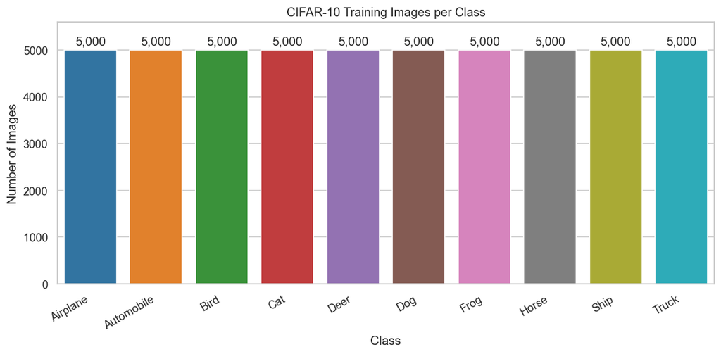

```python
class_counts = np.bincount(y_train, minlength=len(CLASS_NAMES))

class_distribution = pd.DataFrame({
    "Label": np.arange(len(CLASS_NAMES)),
    "Class": CLASS_NAMES,
    "Count": class_counts,
    "Percentage": class_counts / len(y_train) * 100
})

display(class_distribution)

plt.figure(figsize=(10, 5))

ax = sns.barplot(
    data=class_distribution,
    x="Class",
    y="Count",
    hue="Class",
    palette="tab10",
    legend=False
)

for bar, count in zip(ax.patches, class_distribution["Count"]):
    ax.text(
        bar.get_x() + bar.get_width() / 2,
        bar.get_height() + 60,
        f"{count:,}",
        ha="center",
        va="bottom"
    )

plt.title("CIFAR-10 Training Images per Class")
plt.xlabel("Class")
plt.ylabel("Number of Images")
plt.ylim(0, class_distribution["Count"].max() * 1.12)
plt.xticks(rotation=30, ha="right")
plt.tight_layout()
plt.show()
```

**Interpretation**

Each CIFAR-10 class contains 5,000 training images, representing 10% of the training set.

The training data is therefore perfectly balanced across all 10 classes. No class weighting, oversampling, or undersampling is required.

This also supports fair class-wise evaluation later, since differences in generated quality should not be caused by unequal training sample counts.

Class balance alone does not indicate which classes will be easier or harder to generate. That will depend on visual diversity, structural consistency, similarity to other classes, and model outputs.

### 3.2 Representative Images and Within-Class Diversity

A reproducible sample of training images is displayed for each CIFAR-10 class to establish a visual baseline before more detailed analysis.

Random sampling is used instead of manually selecting only clear examples. This allows the grid to reflect realistic variation in:

- pose and viewpoint
- object size and position
- cropping
- colour and lighting
- background complexity
- image clarity
- number of visible objects

The grid is also used to examine within-class diversity and the natural ambiguity present in some real CIFAR-10 images. These observations will later support the evaluation of generated-image recognisability, diversity, and class coverage.

[figure not shown]

```python
images_per_class = 6
rng = np.random.default_rng(SEED)

fig, axes = plt.subplots(
    nrows=len(CLASS_NAMES),
    ncols=images_per_class,
    figsize=(12, 18)
)

for class_id, class_name in enumerate(CLASS_NAMES):
    class_indices = np.where(y_train == class_id)[0]

    sampled_indices = rng.choice(
        class_indices,
        size=images_per_class,
        replace=False
    )

    for column, image_index in enumerate(sampled_indices):
        ax = axes[class_id, column]
        ax.imshow(x_train_uint8[image_index])
        ax.axis("off")

        if column == 0:
            ax.text(
                -0.15,
                0.5,
                class_name,
                transform=ax.transAxes,
                ha="right",
                va="center",
                fontsize=10,
                fontweight="bold",
                clip_on=False
            )

plt.suptitle(
    "Representative CIFAR-10 Training Images by Class",
    fontsize=15,
    fontweight="bold",
    y=1.01
)

plt.tight_layout(rect=[0.10, 0, 1, 0.98])
plt.show()
```

**Interpretation**

The sampled images show substantial variation within every CIFAR-10 class, including differences in pose, viewpoint, object size, crop, colour, and background.

Vehicle classes such as automobile, ship, and truck generally show more consistent large-scale shapes, although they still vary in orientation and surrounding environment. Animal classes, particularly bird, cat, deer, and dog, show wider variation in appearance and pose, with several images where the object is small, blurred, cropped, or difficult to separate from the background.

Some examples in the representative grid also appear blurred, cropped, small, or background-dominated. The following panel examines this quality range more directly and provides a reference for later manual evaluation.

The grid provides preliminary evidence about within-class complexity, but it cannot determine which classes are easier or harder to generate. That must be confirmed using outputs from the GAN and VAE.

### 3.2.1 Clear and Ambiguous Real Examples

Real CIFAR-10 images vary in recognisability even when their class labels are correct.

The first row shows clearly recognisable training images. The second row shows valid training images where blur, cropping, limited detail, or background dominance makes the class harder to identify.

These examples provide a realistic reference for the later manual evaluation of generated images. The panel is illustrative and does not estimate how common each quality level is across the full dataset.

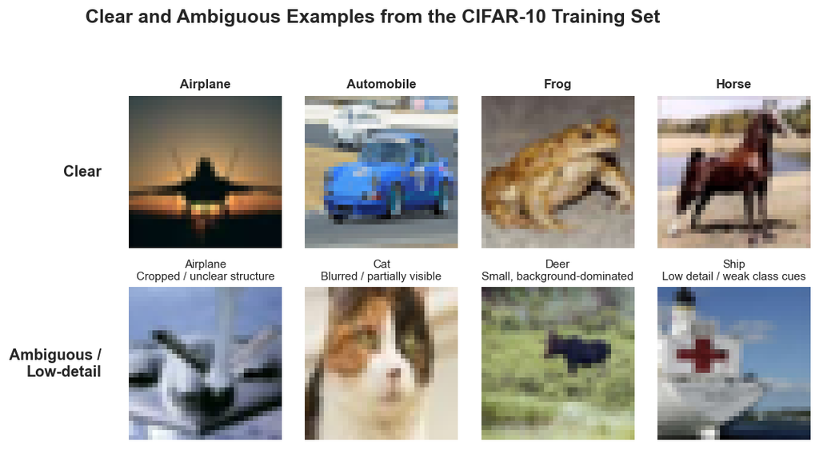

```python
# Recreate the exact samples shown in the representative-image grid
reference_rng = np.random.default_rng(SEED)
representative_indices = {}

for class_id, class_name in enumerate(CLASS_NAMES):
    class_indices = np.where(y_train == class_id)[0]

    representative_indices[class_name] = reference_rng.choice(
        class_indices,
        size=images_per_class,
        replace=False
    )


# Four clearly recognisable examples from the existing grid
clear_examples = [
    ("Airplane", representative_indices["Airplane"][0]),
    ("Automobile", representative_indices["Automobile"][1]),
    ("Frog", representative_indices["Frog"][2]),
    ("Horse", representative_indices["Horse"][0])
]


# Four weaker or ambiguous examples from the existing grid
ambiguous_examples = [
    (
        "Airplane",
        representative_indices["Airplane"][5],
        "Cropped / unclear structure"
    ),
    (
        "Cat",
        representative_indices["Cat"][1],
        "Blurred / partially visible"
    ),
    (
        "Deer",
        representative_indices["Deer"][5],
        "Small, background-dominated"
    ),
    (
        "Ship",
        representative_indices["Ship"][5],
        "Low detail / weak class cues"
    )
]


fig, axes = plt.subplots(
    nrows=2,
    ncols=4,
    figsize=(10, 5)
)


# Display clear examples
for column, (class_name, image_index) in enumerate(clear_examples):
    axes[0, column].imshow(x_train_uint8[image_index])
    axes[0, column].set_title(
        class_name,
        fontsize=10,
        fontweight="bold"
    )
    axes[0, column].axis("off")


# Display ambiguous or low-detail examples
for column, (
    class_name,
    image_index,
    reason
) in enumerate(ambiguous_examples):

    axes[1, column].imshow(x_train_uint8[image_index])
    axes[1, column].set_title(
        f"{class_name}\n{reason}",
        fontsize=9
    )
    axes[1, column].axis("off")


# Add row labels
axes[0, 0].text(
    -0.18,
    0.5,
    "Clear",
    transform=axes[0, 0].transAxes,
    ha="right",
    va="center",
    fontweight="bold",
    clip_on=False
)

axes[1, 0].text(
    -0.18,
    0.5,
    "Ambiguous /\nLow-detail",
    transform=axes[1, 0].transAxes,
    ha="right",
    va="center",
    fontweight="bold",
    clip_on=False
)


plt.suptitle(
    "Clear and Ambiguous Examples from the CIFAR-10 Training Set",
    fontsize=15,
    fontweight="bold"
)

plt.tight_layout(rect=[0.08, 0, 1, 0.93])
plt.show()
```

**Interpretation**

The clear examples retain recognisable object structure despite CIFAR-10’s low `32 × 32` resolution. The airplane has a distinct silhouette, the automobile and horse preserve strong overall shapes, and the frog remains identifiable through its body form and texture.

The ambiguous examples are harder to recognise for different reasons. The airplane is heavily cropped, the cat is blurred and only partly visible, the deer is small relative to the background, and the ship contains limited class-specific detail. These are still valid real training images, showing that CIFAR-10 itself contains a range of image quality and recognisability.

This provides a realistic reference for later manual evaluation. A generated image may be considered **marginal** when it contains plausible class-related features but lacks enough clear structure for confident recognition. However, generated images with no coherent object or class cues should still be classified as **nonsense**.

### 3.3 Class Mean Images and Variation Maps

Class mean images and pixelwise variation maps are used to summarise broad visual patterns within each CIFAR-10 class.

A class mean image is produced by averaging all training images belonging to the same class. This can reveal broad colour and spatial tendencies, although averaging removes most fine object detail.

A variation map measures the standard deviation of pixel values across images in the same class. Brighter regions indicate areas with greater variation in object position, shape, colour, or background.

Together, these outputs help examine:

- broad class-level colour patterns
- spatial consistency within each class
- variation in object position and background
- whether some classes have more stable low-level structure than others

These summaries describe pixel-level patterns and cannot determine generation difficulty by themselves.

```python
class_mean_images = []
class_variation_maps = []

for class_id in range(len(CLASS_NAMES)):
    class_images = (
        x_train_uint8[y_train == class_id].astype("float32") / 255.0
    )

    # Average RGB image for the class
    class_mean_images.append(class_images.mean(axis=0))

    # Pixelwise standard deviation, averaged across RGB channels
    variation_map = class_images.std(axis=0).mean(axis=2)
    class_variation_maps.append(variation_map)

class_mean_images = np.array(class_mean_images)
class_variation_maps = np.array(class_variation_maps)
```

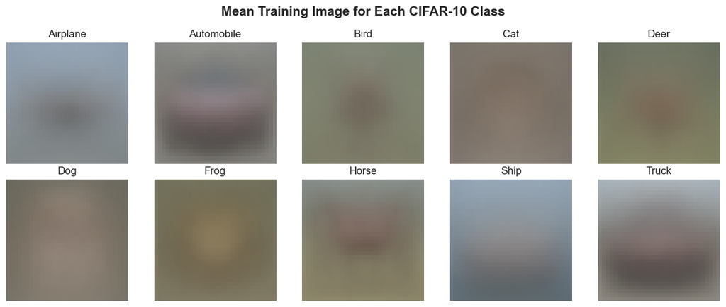

```python
fig, axes = plt.subplots(2, 5, figsize=(12, 5))

for class_id, ax in enumerate(axes.flat):
    ax.imshow(class_mean_images[class_id])
    ax.set_title(CLASS_NAMES[class_id])
    ax.axis("off")

plt.suptitle(
    "Mean Training Image for Each CIFAR-10 Class",
    fontsize=15,
    fontweight="bold"
)

plt.tight_layout()
plt.show()
```

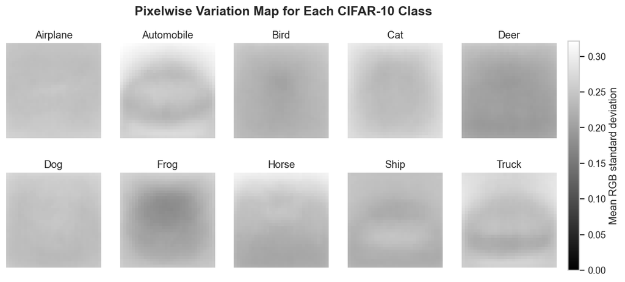

```python
fig, axes = plt.subplots(2, 5, figsize=(12, 5))

shared_max = class_variation_maps.max()

for class_id, ax in enumerate(axes.flat):
    variation_plot = ax.imshow(
        class_variation_maps[class_id],
        cmap="gray",
        vmin=0,
        vmax=shared_max
    )

    ax.set_title(CLASS_NAMES[class_id])
    ax.axis("off")

plt.suptitle(
    "Pixelwise Variation Map for Each CIFAR-10 Class",
    fontsize=15,
    fontweight="bold"
)

fig.colorbar(
    variation_plot,
    ax=axes,
    fraction=0.02,
    pad=0.02,
    label="Mean RGB standard deviation"
)

plt.show()
```

**Interpretation**

The class mean images reveal broad spatial and colour tendencies, but most semantic detail disappears after averaging. Airplane and ship retain a blue upper region and darker lower region, reflecting common sky, sea, and horizon layouts. Automobile and truck show darker regions around the lower centre, suggesting that vehicles are often positioned in a relatively consistent part of the image.

The animal classes produce more diffuse mean images. Their shapes, poses, positions, colours, and backgrounds vary enough that averaging does not preserve a clear object outline. Frog shows a somewhat stronger central concentration, while bird, cat, dog, and deer remain comparatively blurred and spatially less consistent.

The variation maps support this distinction. Automobile, truck, ship, and frog display more recognisable spatial patterns, indicating that some parts of their images are positioned more consistently across the class. Bird, cat, dog, deer, and airplane show more evenly distributed variation, suggesting greater differences in object location, pose, scale, or background.

These results provide evidence about low-level spatial consistency, but they do not prove which classes will be easier to generate. Mean images and variation maps remove semantic detail and combine several sources of variation, including colour, object placement, and background. Final class-difficulty conclusions must therefore be based on generated outputs from both models.

### 3.4 Selected Similar Class Pairs

Several CIFAR-10 classes may share similar shapes, colours, backgrounds, or object structures, especially at the dataset's low resolution.

The following class pairs are compared:

- cat and dog
- deer and horse
- automobile and truck
- airplane and ship

Reproducibly sampled images are used to examine where visual overlap may occur and which distinguishing features may be difficult for a generative model to learn.

This comparison supports preliminary hypotheses about class confusion, but it does not measure model performance or prove that one class will be harder to generate.

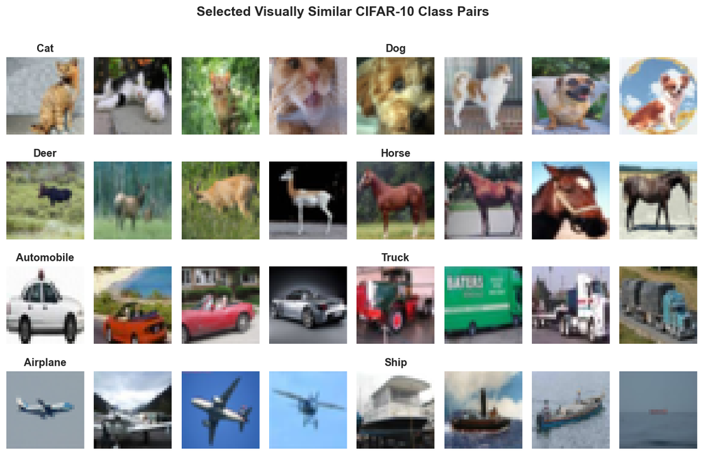

```python
similar_class_pairs = [
    ("Cat", "Dog"),
    ("Deer", "Horse"),
    ("Automobile", "Truck"),
    ("Airplane", "Ship")
]

class_name_to_id = {
    class_name: class_id
    for class_id, class_name in enumerate(CLASS_NAMES)
}

samples_per_class = 4
pair_rng = np.random.default_rng(SEED + 2)

fig, axes = plt.subplots(
    nrows=len(similar_class_pairs),
    ncols=samples_per_class * 2,
    figsize=(14, 8)
)

for row, (class_a, class_b) in enumerate(similar_class_pairs):
    class_a_id = class_name_to_id[class_a]
    class_b_id = class_name_to_id[class_b]

    class_a_indices = np.where(y_train == class_a_id)[0]
    class_b_indices = np.where(y_train == class_b_id)[0]

    sampled_a = pair_rng.choice(
        class_a_indices,
        size=samples_per_class,
        replace=False
    )

    sampled_b = pair_rng.choice(
        class_b_indices,
        size=samples_per_class,
        replace=False
    )

    for column, image_index in enumerate(sampled_a):
        axes[row, column].imshow(x_train_uint8[image_index])
        axes[row, column].axis("off")

    for column, image_index in enumerate(sampled_b):
        plot_column = samples_per_class + column
        axes[row, plot_column].imshow(x_train_uint8[image_index])
        axes[row, plot_column].axis("off")

    axes[row, 0].set_title(class_a, fontweight="bold")
    axes[row, samples_per_class].set_title(
        class_b,
        fontweight="bold"
    )

    axes[row, 0].set_ylabel(
        f"{class_a}\nvs\n{class_b}",
        rotation=0,
        labelpad=45,
        va="center",
        fontweight="bold"
    )

plt.suptitle(
    "Selected Visually Similar CIFAR-10 Class Pairs",
    fontsize=15,
    fontweight="bold"
)

plt.subplots_adjust(left=0.12, wspace=0.08, hspace=0.35)
plt.show()
```

**Interpretation**

The selected pairs show meaningful visual overlap at CIFAR-10's low resolution.

Cat and dog images share similar body shapes, fur colours, poses, and indoor or outdoor backgrounds. Deer and horse images also overlap in body structure, leg placement, and natural scenery, although horses generally appear larger and more elongated.

Automobiles and trucks share wheels, road settings, and horizontal vehicle shapes. Trucks are often larger and more box-like, but some examples remain difficult to separate when the vehicle is small or partially cropped.

Airplanes and ships frequently appear against blue backgrounds. This creates a risk that a model learns sky or water colour as a shortcut instead of learning the object's structure. Their distinguishing cues, such as wings for airplanes and hulls for ships, may occupy only a small number of pixels.

These similarities suggest that class recognisability should be evaluated separately from general realism. A generated image may look plausible but still lack the structural cues needed to distinguish it from a related class.

The comparison supports preliminary class-confusion hypotheses only. Actual difficulty must be confirmed using generated images from the GAN and VAE.

## 4. Pixel, Colour, and Structural Feature Engineering

This section examines the low-level visual properties of the CIFAR-10 training images.

The analysis begins with dataset-wide pixel and RGB distributions before deriving a small set of interpretable image descriptors. These descriptors will later support class-wise analysis and comparisons between real and generated images.

The engineered descriptors are analytical features. They will not be used as direct inputs to the GAN or VAE.

### 4.1 Global Pixel and RGB Distributions

The distribution of pixel values is examined across the complete CIFAR-10 training set.

Separate distributions are calculated for:

- all RGB channel values combined
- the red channel
- the green channel
- the blue channel

This establishes the dataset's overall colour and intensity characteristics and provides a reference for later comparisons with generated images.

A model that produces unusually dark, bright, colour-biased, or low-contrast images may fail to represent the real data distribution even when individual samples appear plausible.

```python
pixel_values = np.arange(256)

pixel_histograms = {
    "Overall": np.bincount(
        x_train_uint8.reshape(-1),
        minlength=256
    ),
    "Red": np.bincount(
        x_train_uint8[..., 0].reshape(-1),
        minlength=256
    ),
    "Green": np.bincount(
        x_train_uint8[..., 1].reshape(-1),
        minlength=256
    ),
    "Blue": np.bincount(
        x_train_uint8[..., 2].reshape(-1),
        minlength=256
    )
}

summary_rows = []

for channel, counts in pixel_histograms.items():
    total = counts.sum()

    mean = np.sum(pixel_values * counts) / total

    variance = np.sum(
        ((pixel_values - mean) ** 2) * counts
    ) / total

    cumulative_counts = np.cumsum(counts)
    median = np.searchsorted(cumulative_counts, total / 2)

    observed_values = np.flatnonzero(counts)

    summary_rows.append({
        "Channel": channel,
        "Mean": mean,
        "Median": median,
        "Standard deviation": np.sqrt(variance),
        "Minimum": observed_values.min(),
        "Maximum": observed_values.max()
    })

pixel_summary = pd.DataFrame(summary_rows)

display(
    pixel_summary.round({
        "Mean": 2,
        "Standard deviation": 2
    })
)
```

|  | Channel | Mean | Median | Standard deviation | Minimum | Maximum |
| --- | --- | --- | --- | --- | --- | --- |
| 0 | Overall | 120.71 | 117 | 64.15 | 0 | 255 |
| 1 | Red | 125.31 | 123 | 62.99 | 0 | 255 |
| 2 | Green | 122.95 | 121 | 62.09 | 0 | 255 |
| 3 | Blue | 113.87 | 104 | 66.70 | 0 | 255 |

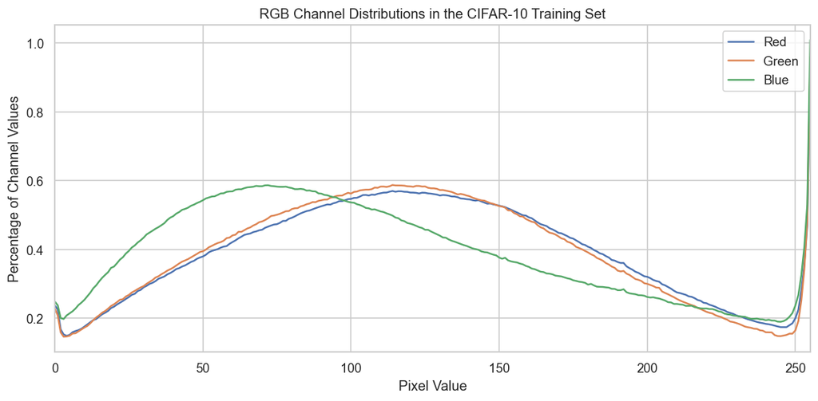

```python
plt.figure(figsize=(10, 5))

for channel in ["Red", "Green", "Blue"]:
    percentages = (
        pixel_histograms[channel]
        / pixel_histograms[channel].sum()
        * 100
    )

    plt.plot(
        pixel_values,
        percentages,
        label=channel
    )

plt.title("RGB Channel Distributions in the CIFAR-10 Training Set")
plt.xlabel("Pixel Value")
plt.ylabel("Percentage of Channel Values")
plt.xlim(0, 255)
plt.legend()
plt.tight_layout()
plt.show()
```

**Interpretation**

All three RGB channels span the full `[0, 255]` range and show broad distributions, confirming that the training set contains substantial variation in colour and intensity.

The red channel has the highest mean value (`125.31`), followed by green (`122.95`), while blue has the lowest mean (`113.87`). The blue distribution is shifted toward lower pixel values and also has the largest standard deviation (`66.70`), indicating a wider spread of blue-channel intensities.

The sharp increase near `255` across all channels shows that fully saturated channel values occur relatively often in the dataset.

These results provide a simple real-data baseline for later checks on whether generated images are systematically too dark, too bright, overly saturated, or biased toward particular colour channels. However, the global distributions do not preserve class or spatial information, so more meaningful image-level differences will be examined using brightness, contrast, saturation, RGB means, and edge strength.

### 4.2 Engineered Image Descriptors

A small set of interpretable descriptors is calculated for every training image.

The descriptors are:

- **Brightness:** mean luminance of the image
- **Contrast:** standard deviation of luminance values
- **Mean red, green, and blue intensity:** average strength of each colour channel
- **Saturation:** average colour intensity using the HSV representation
- **Edge strength:** average Sobel gradient magnitude, representing the amount of visible structural change

All descriptors are calculated using images scaled to the `[0, 1]` range.

These descriptors are not used as direct inputs to the GAN or VAE. They are retained for:

- comparing low-level properties across classes
- supporting preliminary class-difficulty hypotheses
- detecting washed-out, colour-biased, or structurally weak generated images
- comparing real and generated image distributions later

```python
descriptor_batches = []
batch_size = 1000

for start in range(0, len(x_train_uint8), batch_size):
    end = start + batch_size

    images = tf.convert_to_tensor(
        x_train_uint8[start:end],
        dtype=tf.float32
    ) / 255.0

    # Mean RGB intensities
    rgb_means = tf.reduce_mean(images, axis=[1, 2])

    # Luminance using standard RGB weights
    luminance = (
        0.2126 * images[..., 0]
        + 0.7152 * images[..., 1]
        + 0.0722 * images[..., 2]
    )

    brightness = tf.reduce_mean(luminance, axis=[1, 2])
    contrast = tf.math.reduce_std(luminance, axis=[1, 2])

    # Mean HSV saturation
    hsv_images = tf.image.rgb_to_hsv(images)
    saturation = tf.reduce_mean(
        hsv_images[..., 1],
        axis=[1, 2]
    )

    # Sobel edge magnitude
    sobel_edges = tf.image.sobel_edges(
        luminance[..., tf.newaxis]
    )

    edge_magnitude = tf.sqrt(
        tf.reduce_sum(tf.square(sobel_edges), axis=-1)
    )

    edge_strength = tf.reduce_mean(
        edge_magnitude,
        axis=[1, 2, 3]
    )

    descriptor_batches.append(
        np.column_stack([
            brightness.numpy(),
            contrast.numpy(),
            rgb_means.numpy(),
            saturation.numpy(),
            edge_strength.numpy()
        ])
    )

descriptor_values = np.vstack(descriptor_batches)

image_descriptors = pd.DataFrame({
    "Class ID": y_train,
    "Class": CLASS_NAMES[y_train],
    "Brightness": descriptor_values[:, 0],
    "Contrast": descriptor_values[:, 1],
    "Mean Red": descriptor_values[:, 2],
    "Mean Green": descriptor_values[:, 3],
    "Mean Blue": descriptor_values[:, 4],
    "Saturation": descriptor_values[:, 5],
    "Edge Strength": descriptor_values[:, 6]
})

display(image_descriptors.head())
```

|  | Class ID | Class | Brightness | Contrast | Mean Red | Mean Green | Mean Blue | Saturation | Edge Strength |
| --- | --- | --- | --- | --- | --- | --- | --- | --- | --- |
| 0 | 6 | Frog | 0.430631 | 0.162135 | 0.553746 | 0.412155 | 0.251125 | 0.573978 | 0.532795 |
| 1 | 9 | Truck | 0.511130 | 0.235559 | 0.510585 | 0.511236 | 0.511677 | 0.175088 | 0.861699 |
| 2 | 9 | Truck | 0.527892 | 0.323579 | 0.523470 | 0.530010 | 0.519943 | 0.127158 | 0.495000 |
| 3 | 4 | Deer | 0.333185 | 0.127280 | 0.392077 | 0.326586 | 0.225152 | 0.433660 | 0.394277 |
| 4 | 1 | Automobile | 0.396768 | 0.222054 | 0.360869 | 0.401570 | 0.454914 | 0.315364 | 0.630970 |

```python
descriptor_columns = [
    "Brightness",
    "Contrast",
    "Mean Red",
    "Mean Green",
    "Mean Blue",
    "Saturation",
    "Edge Strength"
]

# Basic descriptor validation
assert len(image_descriptors) == len(x_train_uint8)
assert np.isfinite(
    image_descriptors[descriptor_columns].to_numpy()
).all()

assert image_descriptors[
    [
        "Brightness",
        "Contrast",
        "Mean Red",
        "Mean Green",
        "Mean Blue",
        "Saturation"
    ]
].apply(lambda column: column.between(0, 1).all()).all()

assert (image_descriptors["Edge Strength"] >= 0).all()

descriptor_summary = (
    image_descriptors[descriptor_columns]
    .agg(["min", "mean", "median", "std", "max"])
    .T
    .rename(columns={
        "min": "Minimum",
        "mean": "Mean",
        "median": "Median",
        "std": "Standard Deviation",
        "max": "Maximum"
    })
)

descriptor_summary["Missing Values"] = (
    image_descriptors[descriptor_columns]
    .isna()
    .sum()
)

descriptor_summary["Non-Finite Values"] = (
    ~np.isfinite(
        image_descriptors[descriptor_columns]
    )
).sum()

display(descriptor_summary.round(4))

assert descriptor_summary["Missing Values"].eq(0).all()
assert descriptor_summary["Non-Finite Values"].eq(0).all()

print("All engineered descriptors were calculated successfully.")
```

|  | Minimum | Mean | Median | Standard Deviation | Maximum | Missing Values | Non-Finite Values |
| --- | --- | --- | --- | --- | --- | --- | --- |
| Brightness | 0.0427 | 0.4816 | 0.4762 | 0.1233 | 0.9898 | 0 | 0 |
| Contrast | 0.0173 | 0.1970 | 0.1954 | 0.0603 | 0.4509 | 0 | 0 |
| Mean Red | 0.0100 | 0.4914 | 0.4868 | 0.1284 | 0.9889 | 0 | 0 |
| Mean Green | 0.0138 | 0.4822 | 0.4775 | 0.1258 | 0.9907 | 0 | 0 |
| Mean Blue | 0.0126 | 0.4465 | 0.4355 | 0.1533 | 0.9914 | 0 | 0 |
| Saturation | 0.0000 | 0.2738 | 0.2551 | 0.1415 | 0.9843 | 0 | 0 |
| Edge Strength | 0.0380 | 0.5183 | 0.5171 | 0.1547 | 1.3284 | 0 | 0 |

```
All engineered descriptors were calculated successfully.
```

The engineered descriptors were calculated successfully for all training images.

No missing or non-finite values were found. Brightness, contrast, RGB means, and saturation remain within their expected `[0, 1]` ranges. Edge strength is non-negative and can exceed `1` because it measures Sobel gradient magnitude rather than normalised pixel intensity.

The mean, median, and standard deviation values also confirm that each descriptor varies meaningfully across the dataset, so the features are suitable for class-wise comparison.

The descriptors will now be compared across classes to examine differences in colour, brightness, contrast, saturation, and structural detail.

### 4.3 Class-Wise Descriptor Distributions

The distributions of brightness, contrast, saturation, and edge strength are compared across the 10 CIFAR-10 classes.

These descriptors were selected because they capture distinct image properties:

- **Brightness:** overall luminance
- **Contrast:** variation between light and dark regions
- **Saturation:** strength of colour information
- **Edge strength:** amount of visible structural change

Class-wise distributions are more informative than class averages alone because they show both typical values and within-class variation.

The analysis investigates whether certain classes consistently differ in colour, intensity, or structural detail, and whether these differences may later help evaluate generated images.

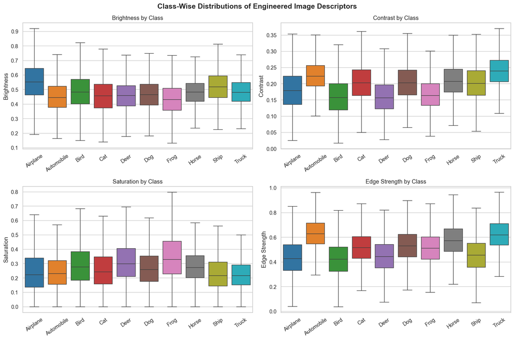

```python
distribution_descriptors = [
    "Brightness",
    "Contrast",
    "Saturation",
    "Edge Strength"
]

fig, axes = plt.subplots(
    nrows=2,
    ncols=2,
    figsize=(15, 10)
)

for ax, descriptor in zip(axes.flat, distribution_descriptors):
    sns.boxplot(
        data=image_descriptors,
        x="Class",
        y=descriptor,
        order=CLASS_NAMES,
        hue="Class",
        hue_order=CLASS_NAMES,
        palette="tab10",
        legend=False,
        showfliers=False,
        ax=ax
    )

    ax.set_title(f"{descriptor} by Class")
    ax.set_xlabel("")
    ax.set_ylabel(descriptor)
    ax.tick_params(axis="x", rotation=35)

plt.suptitle(
    "Class-Wise Distributions of Engineered Image Descriptors",
    fontsize=15,
    fontweight="bold"
)

plt.tight_layout()
plt.show()
```

**Interpretation**

The descriptors differ across classes, but there is also substantial overlap within each distribution.

Airplane and ship images tend to be brighter, while frog images have the lowest median brightness. Brightness still varies widely within every class, showing that lighting and background conditions are not consistent.

Truck has the highest median contrast, followed by automobile, horse, cat, dog, and ship. Bird, deer, and frog generally have lower contrast. The vehicle classes also show relatively strong edge values, particularly automobile and truck, which is consistent with their more rigid shapes and defined boundaries.

Frog has the highest saturation, while ship and truck have the lowest median saturation. This suggests that colour strength differs meaningfully between classes and may provide useful evidence when evaluating generated images.

The strong overlap between classes shows that these descriptors cannot determine class identity or generation difficulty on their own. Their main value is as class-specific reference distributions for detecting generated images that are unusually dark, washed out, weakly structured, or colour-biased.

### 4.4 Class Descriptor Profile

The mean descriptor values for each class are combined into a single profile.

Because the descriptors use different numerical scales, each descriptor column is standardised before visualisation. Positive values indicate that a class is above the overall class mean for that descriptor, while negative values indicate that it is below the overall class mean.

The heatmap provides a compact summary of how the classes differ across colour, brightness, contrast, saturation, and edge strength together.

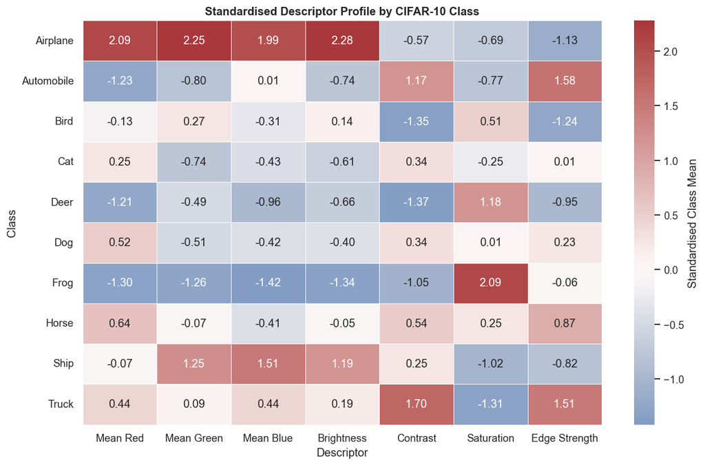

```python
profile_descriptors = [
    "Mean Red",
    "Mean Green",
    "Mean Blue",
    "Brightness",
    "Contrast",
    "Saturation",
    "Edge Strength"
]

class_descriptor_profile = (
    image_descriptors
    .groupby("Class")[profile_descriptors]
    .mean()
    .reindex(CLASS_NAMES)
)

standardised_profile = (
    class_descriptor_profile - class_descriptor_profile.mean()
) / class_descriptor_profile.std(ddof=0)

plt.figure(figsize=(11, 7))

sns.heatmap(
    standardised_profile,
    annot=True,
    fmt=".2f",
    center=0,
    cmap="vlag",
    linewidths=0.5,
    cbar_kws={
        "label": "Standardised Class Mean"
    }
)

plt.title(
    "Standardised Descriptor Profile by CIFAR-10 Class",
    fontweight="bold"
)
plt.xlabel("Descriptor")
plt.ylabel("Class")
plt.tight_layout()
plt.show()
```

**Interpretation**

The heatmap shows distinct class-level visual profiles across the engineered descriptors.

Automobile and truck show the strongest contrast and edge-strength profiles. Their rigid shapes, wheels, and defined vehicle boundaries likely produce stronger structural changes than many animal classes. Truck has the highest relative contrast, while automobile also shows strongly above-average edge strength.

Frog has the highest saturation profile despite having below-average brightness and RGB means. This suggests that frog images tend to contain stronger colour differences rather than simply higher overall channel intensities. Deer also shows above-average saturation but relatively low contrast and edge strength.

The remaining animal classes have more moderate or mixed profiles. Horse has above-average contrast and edge strength, while bird has relatively weak contrast and edge strength. Cat and dog remain closer to the overall averages across several descriptors, which may make them less distinguishable using low-level properties alone.

These profiles provide useful class-specific reference points for later generated-image evaluation. However, the values are standardised relative to the 10 class means and do not measure recognisability or semantic quality. They should not be used alone to determine which classes are easier or harder to generate.

### 4.5 Descriptor Retention and Reuse

The engineered descriptors are reviewed based on whether they provide distinct information and have a clear use later in the project.

| Descriptor | Distinct information | Later use | Decision |
| --- | --- | --- | --- |
| Brightness | Overall perceptual luminance | Detect generated images that are systematically too dark or bright | Retain |
| Contrast | Variation between light and dark regions | Detect flat or washed-out generated images | Retain |
| Mean RGB intensities | Average channel balance | Detect colour bias and compare real-versus-generated colour distributions | Retain |
| Saturation | Strength of colour information | Support grayscale analysis and detect weak or excessive colour in generated images | Retain |
| Edge strength | Amount of local structural change | Compare sharpness and detect blurred or structurally weak outputs | Retain |

Although brightness is derived from the RGB channels, it is retained because it represents perceptual luminance rather than individual channel balance.

The descriptors will not be used as direct GAN or VAE inputs. They will serve as supplementary evaluation evidence alongside visual inspection, class coverage, diversity analysis, FID, and the memorisation audit.

## 5. Task-Specific Exploratory Analysis

This section investigates questions that directly relate to the assignment requirements.

The analysis examines:

- how converting CIFAR-10 images to grayscale affects visible information
- whether selected augmentations preserve class identity
- which classes may be easier or harder to generate based on the EDA evidence

These findings will guide later GAN and VAE experiments, but final conclusions must still be supported by generated outputs.

### 5.1 RGB Versus Grayscale

CIFAR-10 images are originally represented using three RGB channels. Converting them to grayscale reduces each image to one luminance channel.

This may simplify the generation task by removing the need to learn colour relationships. However, it may also remove useful cues that help distinguish objects, backgrounds, and visually similar classes.

Representative images from several classes are compared in RGB and grayscale to examine:

- which visual structures remain recognisable
- which colour cues are lost
- whether object-background separation becomes weaker
- whether grayscale could reduce class recognisability

No grayscale model is trained in this notebook.

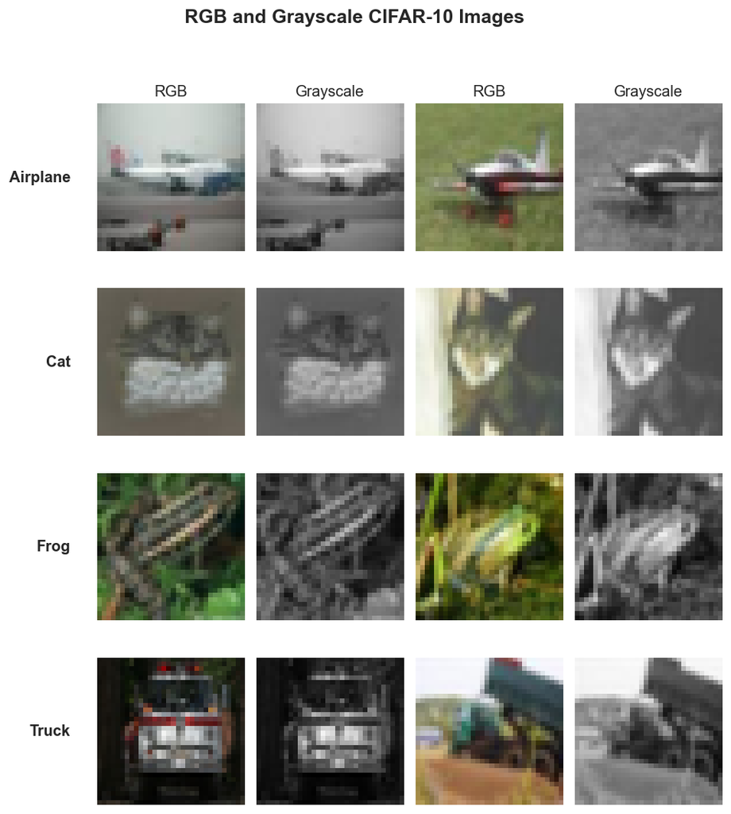

```python
grayscale_classes = [
    "Airplane",
    "Cat",
    "Frog",
    "Truck"
]

samples_per_class = 2
grayscale_rng = np.random.default_rng(SEED + 3)

class_name_to_id = {
    class_name: class_id
    for class_id, class_name in enumerate(CLASS_NAMES)
}

fig, axes = plt.subplots(
    nrows=len(grayscale_classes),
    ncols=samples_per_class * 2,
    figsize=(10, 10)
)

for row, class_name in enumerate(grayscale_classes):
    class_id = class_name_to_id[class_name]
    class_indices = np.where(y_train == class_id)[0]

    sampled_indices = grayscale_rng.choice(
        class_indices,
        size=samples_per_class,
        replace=False
    )

    for sample_number, image_index in enumerate(sampled_indices):
        rgb_column = sample_number * 2
        grayscale_column = rgb_column + 1

        rgb_image = x_train_uint8[image_index]

        grayscale_image = tf.image.rgb_to_grayscale(
            rgb_image
        ).numpy().squeeze()

        axes[row, rgb_column].imshow(rgb_image)
        axes[row, rgb_column].axis("off")

        axes[row, grayscale_column].imshow(
            grayscale_image,
            cmap="gray",
            vmin=0,
            vmax=255
        )
        axes[row, grayscale_column].axis("off")

        if row == 0:
            axes[row, rgb_column].set_title("RGB")
            axes[row, grayscale_column].set_title("Grayscale")

    axes[row, 0].text(
        -0.18,
        0.5,
        class_name,
        transform=axes[row, 0].transAxes,
        ha="right",
        va="center",
        fontweight="bold",
        clip_on=False
    )

plt.suptitle(
    "RGB and Grayscale CIFAR-10 Images",
    fontsize=15,
    fontweight="bold"
)

plt.subplots_adjust(left=0.22, wspace=0.08, hspace=0.20)
plt.show()
```

**Interpretation**

The grayscale versions preserve the main shapes and broad object structure, especially for the airplane and truck examples. These classes remain reasonably recognisable because their identity depends strongly on rigid outlines and geometry.

The cat and frog examples lose more useful information. Their original colours help separate the animals from the background, while grayscale reduces this distinction and makes some details harder to identify at the already limited 32 × 32 resolution.

Grayscale would simplify the generation task by reducing three colour channels to one, but it would also remove information that supports object-background separation and class recognition. For this project, retaining RGB is more appropriate because colour is a meaningful part of the CIFAR-10 distribution and the assignment requires colour-image generation.

These examples are illustrative rather than proof that every class is affected equally.

### 5.2 Augmentation Suitability

Data augmentation may introduce useful variation during training, but unsuitable transformations can distort the small CIFAR-10 images or weaken class identity.

A restrained set of candidate augmentations is previewed:

- horizontal flipping
- small translation
- limited crop and resize
- mild brightness adjustment
- mild contrast adjustment

The purpose is not to assume that augmentation will improve either model. Each transformation will first be checked visually, then tested through controlled experiments in the GAN or VAE notebooks if it remains suitable.

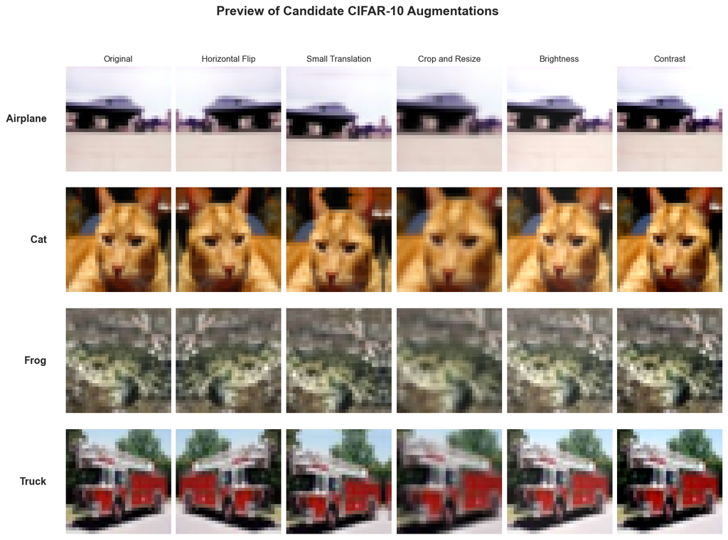

```python
augmentation_rng = np.random.default_rng(SEED + 4)

augmentation_classes = [
    "Airplane",
    "Cat",
    "Frog",
    "Truck"
]

sample_indices = []

for class_name in augmentation_classes:
    class_id = class_name_to_id[class_name]
    class_indices = np.where(y_train == class_id)[0]

    sample_indices.append(
        augmentation_rng.choice(class_indices)
    )

augmentation_names = [
    "Original",
    "Horizontal Flip",
    "Small Translation",
    "Crop and Resize",
    "Brightness",
    "Contrast"
]

fig, axes = plt.subplots(
    nrows=len(sample_indices),
    ncols=len(augmentation_names),
    figsize=(15, 10)
)

for row, image_index in enumerate(sample_indices):
    image = tf.cast(x_train_uint8[image_index], tf.float32) / 255.0

    # Shift two pixels downward and two pixels left, using reflected padding instead of wrap-around
    padded_image = tf.pad(
        image,
        paddings=[[2, 2], [2, 2], [0, 0]],
        mode="REFLECT"
    )

    translated = padded_image[
        0:32,
        4:36,
        :
    ]

    cropped = tf.image.central_crop(
        image,
        central_fraction=0.875
    )
    cropped = tf.image.resize(cropped, [32, 32])

    augmented_images = [
        image,
        tf.image.flip_left_right(image),
        translated,
        cropped,
        tf.image.adjust_brightness(image, 0.08),
        tf.image.adjust_contrast(image, 1.15)
    ]

    for column, augmented_image in enumerate(augmented_images):
        axes[row, column].imshow(
            tf.clip_by_value(augmented_image, 0, 1)
        )
        axes[row, column].axis("off")

        if row == 0:
            axes[row, column].set_title(
                augmentation_names[column],
                fontsize=10
            )

    axes[row, 0].text(
        -0.18,
        0.5,
        augmentation_classes[row],
        transform=axes[row, 0].transAxes,
        ha="right",
        va="center",
        fontweight="bold",
        clip_on=False
    )

plt.suptitle(
    "Preview of Candidate CIFAR-10 Augmentations",
    fontsize=15,
    fontweight="bold"
)

plt.subplots_adjust(left=0.18, wspace=0.05, hspace=0.15)
plt.show()
```

**Interpretation**

Horizontal flipping preserves the main object structure and class identity across the examples, while introducing realistic viewpoint variation. It is therefore a suitable candidate for controlled testing.

The small translation also preserves recognisability after reflected padding is used, making it a reasonable way to reduce dependence on fixed object positions.

Crop and resize remains more questionable. Although the examples are still recognisable, the transformation enlarges and slightly softens the already low-resolution images. Stronger cropping could remove important class cues, so it should not be enabled by default.

Mild brightness and contrast adjustments preserve recognisability in these examples and may help the models handle lighting variation. However, excessive adjustment could shift the generated distribution away from real CIFAR-10 images.

Horizontal flipping, small translation, and mild brightness or contrast adjustment will therefore be retained as candidates for controlled experiments. Crop and resize will only be tested if there is a clear reason to include it. Visual suitability alone does not prove that augmentation improves generative performance.

### 5.3 Preliminary Class-Difficulty Hypotheses

The EDA suggests that classes with more consistent shapes and stronger structural cues, such as automobile and truck, may be easier to generate recognisably.

Classes such as cat, dog, bird, and deer may be more difficult because they show greater variation in pose, appearance, background, and similarity to related classes.

Airplane, ship, frog, and horse show mixed evidence. Their broad structure or colour patterns may help generation, but background dependence and similarity to other classes could still reduce recognisability.

These are preliminary hypotheses only. Final conclusions will be based on generated outputs, class coverage, diversity, and manual recognisability scoring from both the GAN and VAE.

## 6. Implications for GAN and VAE Development

The EDA findings have several implications for the later GAN and VAE experiments.

### 6.1 GAN Implications

The GAN must capture substantial variation within each class while avoiding repeated or overly similar outputs.

The strong overlap between related classes, such as cat and dog or automobile and truck, means that visual realism alone will not be sufficient. Generated images must also contain recognisable class-specific structure.

The GAN experiments should therefore monitor:

- mode collapse and repeated outputs
- class coverage
- generator and discriminator balance
- fixed-seed image progression
- background shortcuts
- recognisability of related classes

Horizontal flipping, small translation, and mild brightness or contrast adjustments may be tested as controlled augmentation experiments. None should be enabled automatically without evidence of improvement.

### 6.2 VAE Implications

The wide variation in pose, colour, background, and object position may make accurate reconstruction difficult, particularly for animal classes.

Since CIFAR-10 images are already low resolution, excessive reconstruction smoothing may remove important class cues. The VAE experiments should therefore examine:

- reconstruction sharpness
- edge preservation
- colour preservation
- reconstruction and KL-divergence balance
- latent-space utilisation
- posterior collapse
- class coverage in generated samples

Latent dimensionality should be selected through controlled experiments rather than inferred from the EDA alone.

### 6.3 Shared Evaluation Implications

Both models must be evaluated using more than training losses.

The shared evaluation should include:

- visual quality
- structured clear, marginal, and nonsense scoring calibrated using the real-image reference panel
- class recognisability
- diversity and repetition
- class coverage
- development FID
- real-versus-generated descriptor comparisons
- nearest-neighbour memorisation checks

Brightness, contrast, RGB means, saturation, and edge strength will be reused as supplementary evidence when comparing generated images with the real training distribution.

The official test set remains reserved for the final held-out comparison after both model pipelines and evaluation procedures are locked.

## 7. Shared Preprocessing and Evaluation Rules

The GAN and VAE use different native input ranges, but both must begin from the same original CIFAR-10 training images and remain compatible with a shared evaluation pipeline.

This section defines the common data rules and validates the model-specific preprocessing conversions.

### 7.1 Locked Shared Decisions

The following decisions apply to both model tracks:

- both models use the official 50,000 CIFAR-10 training images
- the official test set is not used for training or development decisions
- no external image data is used
- images remain RGB with shape `32 × 32 × 3`
- the original `uint8` images in the `[0, 255]` range are preserved
- the same class names and class order are used throughout the project
- labels remain available for class-wise analysis and conditional modelling
- model outputs must be convertible into the same representation for final evaluation

Model-specific choices such as conditional generation, augmentation, batching, and architecture details will be decided in the GAN and VAE notebooks.

### 7.2 GAN and VAE Preprocessing

The GAN and VAE require different numerical input ranges.

For the GAN, images are converted from `uint8` values in `[0, 255]` to `float32` values in `[-1, 1]`. This is compatible with a generator using a `tanh` output activation.

For the VAE, images are converted from `uint8` values in `[0, 255]` to `float32` values in `[0, 1]`. This is compatible with a decoder using a sigmoid output activation.

The original image arrays remain unchanged. Separate preprocessing and restoration functions are defined so that both model outputs can later be converted into a common representation for visualisation and evaluation.

```python
# Convert uint8 images from [0, 255] to float32 [-1, 1].
def preprocess_for_gan(images):
    return images.astype("float32") / 127.5 - 1.0

# Convert GAN images from [-1, 1] to uint8 [0, 255].
def restore_from_gan(images):
    restored = (images + 1.0) * 127.5
    return np.clip(
        np.rint(restored),
        0,
        255
    ).astype("uint8")

# Convert uint8 images from [0, 255] to float32 [0, 1].
def preprocess_for_vae(images):
    return images.astype("float32") / 255.0

# Convert VAE images from [0, 1] to uint8 [0, 255].
def restore_from_vae(images):
    restored = images * 255.0
    return np.clip(
        np.rint(restored),
        0,
        255
    ).astype("uint8")
```

### 7.3 Preprocessing Validation

The GAN and VAE preprocessing functions are validated using a reproducible sample of training images.

Each sample is converted to its model-specific numerical range and then restored to the original `uint8` representation.

The validation checks:

- output data type
- expected numerical range
- exact recovery of the original image values

This confirms that the preprocessing rules are implemented correctly before they are used in the individual model notebooks.

```python
# Validate using a reproducible sample
validation_indices = np.random.default_rng(SEED).choice(
    len(x_train_uint8),
    size=16,
    replace=False
)

validation_images = x_train_uint8[validation_indices]

gan_images = preprocess_for_gan(validation_images)
vae_images = preprocess_for_vae(validation_images)

gan_restored = restore_from_gan(gan_images)
vae_restored = restore_from_vae(vae_images)

assert gan_images.dtype == np.float32
assert vae_images.dtype == np.float32

assert gan_images.min() >= -1
assert gan_images.max() <= 1

assert vae_images.min() >= 0
assert vae_images.max() <= 1

assert np.array_equal(
    validation_images,
    gan_restored
)

assert np.array_equal(
    validation_images,
    vae_restored
)

print(
    "GAN range:",
    gan_images.min(),
    "to",
    gan_images.max()
)

print(
    "VAE range:",
    vae_images.min(),
    "to",
    vae_images.max()
)

print(
    "GAN round-trip maximum difference:",
    np.abs(
        validation_images.astype(int)
        - gan_restored.astype(int)
    ).max()
)

print(
    "VAE round-trip maximum difference:",
    np.abs(
        validation_images.astype(int)
        - vae_restored.astype(int)
    ).max()
)

print("Both preprocessing pipelines passed validation.")
```

```
GAN range: -1.0 to 1.0
VAE range: 0.0 to 1.0
GAN round-trip maximum difference: 0
VAE round-trip maximum difference: 0
Both preprocessing pipelines passed validation.
```

**Interpretation**

Both preprocessing pipelines produced the intended `float32` ranges and preserved the original image values exactly after inverse conversion.

The GAN pipeline maps images to `[-1, 1]`, while the VAE pipeline maps images to `[0, 1]`. The maximum round-trip difference of `0` confirms that neither conversion introduces information loss for the tested images.

### 7.4 Shared Evaluation Conversion

GAN and VAE outputs will use different native numerical ranges. Before shared evaluation, both outputs must therefore be converted into the same image representation.

Real images, GAN-generated images, and VAE-generated images will use the same:

- RGB colour mode
- image dimensions
- channel ordering
- numerical range
- data type
- resizing and feature-extractor preprocessing, where required

For visualisation and saved outputs, images will be converted to `uint8` values in the `[0, 255]` range.

For FID and the nearest-neighbour memorisation audit, all image sources will pass through one identical evaluation pipeline. This prevents either model from receiving favourable treatment because of differences in its native output range.

### 7.5 Shared Preprocessing and Evaluation Summary

The main preprocessing and evaluation rules are summarised below to ensure that the GAN and VAE use the same data source and are compared fairly.

| Item | GAN | VAE | Shared rule |
| --- | --- | --- | --- |
| Training data | Official 50,000 training images | Official 50,000 training images | Same training source |
| Model input range | `[-1, 1]` | `[0, 1]` | Model-specific scaling |
| Image format | `32 × 32 × 3` RGB | `32 × 32 × 3` RGB | Same shape and colour mode |
| Test-set use | Final held-out evaluation only | Final held-out evaluation only | No development use |
| Evaluation conversion | Converted from GAN output range | Converted from VAE output range | Identical evaluation representation |

Model-specific decisions such as conditional generation, augmentation, batching, and output activations will be finalised in the respective GAN and VAE notebooks.

## 8. Final Findings and Handoff

This section consolidates the main findings from the EDA, feature engineering, and preprocessing stages.

The purpose is to show how the observed dataset characteristics affect later modelling and evaluation decisions, without repeating the full analysis.

### 8.1 EDA Finding-to-Decision Summary

| Finding | Evidence | Decision or later use |
| --- | --- | --- |
| The training set is perfectly balanced | Each class contains 5,000 training images | No class weighting, oversampling, or undersampling is required |
| No exact duplicate training images were found | Exact duplicate check returned zero duplicate groups | No duplicate-related cleaning is required |
| CIFAR-10 contains substantial within-class variation | Representative samples varied in pose, crop, colour, scale, and background | Generated images must be evaluated for diversity and not only visual quality |
| Some real images are already ambiguous or low-detail | The clear-versus-ambiguous panel showed blurred, cropped, low-detail, and background-dominated real images | Calibrate later clear and marginal scoring against realistic CIFAR-10 quality, while reserving nonsense for outputs without coherent object cues |
| Vehicle classes show relatively consistent large-scale structure | Automobile, truck, and ship retained clearer spatial patterns in mean images and variation maps | These classes may be easier to generate recognisably, but this remains a hypothesis |
| Animal classes show greater variation in pose and appearance | Bird, cat, dog, and deer produced more diffuse class summaries | These classes may require greater model capacity and careful class-wise evaluation |
| Selected class pairs share strong visual similarities | Cat-dog, deer-horse, automobile-truck, and airplane-ship showed overlapping cues | Class recognisability must be assessed separately from general image realism |
| Colour contains useful class and background information | RGB distributions, saturation profiles, and RGB-grayscale comparisons | Images will remain RGB rather than being converted to grayscale |
| Brightness, contrast, colour, saturation, and edge strength differ across classes | Class-wise boxplots and descriptor heatmap | These descriptors will be reused for real-versus-generated comparisons |
| Horizontal flipping and small translation preserve class identity | Augmentation previews retained recognisable objects | Test these augmentations through controlled model experiments |
| Mild brightness and contrast changes remain plausible | Previewed transformations preserved recognisability | Retain as optional controlled experiments, not default preprocessing |
| GAN and VAE require different input ranges | Preprocessing validation confirmed exact round-trip conversion | Use `[-1, 1]` for GAN and `[0, 1]` for VAE, then convert both into one shared evaluation representation |

### 8.2 Feature Reuse Summary

The engineered descriptors retained from the EDA will be reused as supplementary evaluation evidence for generated images.

| Descriptor | Purpose in EDA | Later use |
| --- | --- | --- |
| Brightness | Measure overall luminance | Detect images that are systematically too dark or bright |
| Contrast | Measure variation between light and dark regions | Detect flat or washed-out outputs |
| Mean RGB intensities | Measure average colour balance | Identify colour-channel bias |
| Saturation | Measure colour strength | Detect weak, excessive, or unrealistic colour |
| Edge strength | Measure local structural change | Compare sharpness and identify blurred outputs |

These descriptors will not replace visual inspection, FID, class coverage, or diversity analysis. They will be used as supporting evidence when comparing real and generated image distributions.

### 8.3 Retained, Rejected, and Deferred Decisions

The final notebook scope was selected based on whether each item answered a distinct question, supported a later decision, or could be reused during model evaluation.

| Status | Decision | Reason or next step |
| --- | --- | --- |
| Retained | Brightness, contrast, mean RGB intensity, saturation, and edge strength | These interpretable descriptors capture distinct image properties and will later support real-versus-generated comparisons |
| Retained | RGB image generation | Colour contributes useful object and background information that is lost in grayscale |
| Retained for testing | Horizontal flipping, small translation, and mild brightness or contrast adjustment | These transformations preserved class identity, but their benefit must be confirmed through controlled model experiments |
| Rejected as default | Crop and resize augmentation | It may remove details and increase blur at the low `32 × 32` resolution |
| Excluded | Entropy, PCA, raw-pixel dimensionality reduction, and additional centroid-based analyses | Existing visual analysis, descriptor distributions, and the class-profile heatmap already answer the relevant questions more directly |
| Deferred | Final augmentation choices and easier or harder class conclusions | These require evidence from trained GAN and VAE models |
| Deferred | Architecture, latent dimension, optimisation settings, conditional generation, FID, manual scoring, and memorisation analysis | These will be finalised and evaluated in the later modelling and comparison notebooks |

### 8.4 Final Conclusions and Handoff

The CIFAR-10 training set is balanced and structurally valid, so no cleaning, class weighting or resampling is required before model development. The EDA also showed substantial within-class variation in object position, scale, pose, colour, crop, clarity and background. Valid real images can themselves be ambiguous, which provides an important reference for later generated-image assessment.

Vehicle classes generally show more consistent large-scale structure, while several animal classes show greater pose and appearance variation. Similar class pairs such as cat–dog, deer–horse, automobile–truck and airplane–ship may also create recognisability challenges. These remain hypotheses rather than final claims until generated outputs are evaluated.

Brightness, contrast, RGB means, saturation and edge strength are retained as supplementary descriptors for later comparison, but they are not treated as measures of semantic quality. RGB is retained because colour provides useful object and background information. Horizontal flipping, small translation and mild brightness/contrast adjustment remain augmentation candidates, while crop-resize is rejected as a default because of CIFAR-10's low resolution.

The shared preprocessing contract is now established: GAN inputs use `[-1,1]`, VAE inputs use `[0,1]`, both outputs are converted to the same RGB `uint8 [0,255]` representation for shared evaluation, and the official test set remains protected until final held-out comparison.

These findings and preprocessing decisions are carried forward into the GAN and VAE development notebooks. Final conclusions on model superiority, class difficulty, augmentation benefit and the official 1,000-image output are deferred until the corresponding controlled experiments and final comparison are complete.

### 8.5 References

Goodfellow, I.J., Pouget-Abadie, J., Mirza, M., Xu, B., Warde-Farley, D., Ozair, S., Courville, A. and Bengio, Y. (2014) ‘Generative adversarial nets’, *Advances in Neural Information Processing Systems*, 27. Available at: https://proceedings.neurips.cc/paper/5423-generative-adversarial-nets (Accessed: 11 July 2026).

Heusel, M., Ramsauer, H., Unterthiner, T., Nessler, B. and Hochreiter, S. (2017) ‘GANs trained by a two time-scale update rule converge to a local Nash equilibrium’, *Advances in Neural Information Processing Systems*, 30. Available at: https://proceedings.neurips.cc/paper/2017/hash/8a1d694707eb0fefe65871369074926d-Abstract.html (Accessed: 11 July 2026).

Kingma, D.P. and Welling, M. (2014) ‘Auto-encoding variational Bayes’, *International Conference on Learning Representations*. Available at: https://openreview.net/forum?id=33X9fd2-9FyZd (Accessed: 11 July 2026).

Krizhevsky, A. (2009) ‘CIFAR-10 and CIFAR-100 datasets’, *University of Toronto*. Available at: https://www.cs.toronto.edu/~kriz/cifar.html (Accessed: 11 July 2026).

Radford, A., Metz, L. and Chintala, S. (2016) ‘Unsupervised representation learning with deep convolutional generative adversarial networks’, *International Conference on Learning Representations*. Available at: https://arxiv.org/abs/1511.06434 (Accessed: 11 July 2026).

*End of Notebook.*